# PRÀCTICA 1

Laura Julià Melis y Víctor Navarro Garcés

March 23, 2018

1. Cargar los datos en BreenOakWood.xlsx en el entorno R.

```r
data <- read.xlsx("BreenOakwood.xlsx",sheetIndex=1, header=T)
```

2. (1p) Cuantas especies se han encontrado? Cúal és el número total de plantas? En promedio, cuantas plantas se han encontrado de cada especie?

```r
N_especies <- nrow(data)
N_especies
```

```
## [1] 29
```

```r
N_plantas <- sum(data[,2])
N_plantas
```

```
## [1] 884
```

```r
Promedio <- N_plantas/N_especies
round(Promedio,2)
```

```
## [1] 30.48
```

Se han encontrado 29 especies. El número total de plantas ha sido 884. El promedio de plantas por especies es de 30.48.

3. Calcula una nueva variable con la abundancia relativa de cada especie.

La abundancia relativa de cada especie es:

```r
Abun_relativa <- round(data$Abundance/N_plantas,4)
kable(data.frame(data$Species, Abun_relativa))
```

| data.Species | Abun_relativa |
| --- | --- |
| Agrostis tenuis | 0.0158 |
| Anthoxanthus odoratum | 0.0373 |
| Blechnum spicant | 0.0113 |
| Calluna vulgaris | 0.0079 |
| Carex flexuosa | 0.0034 |
| Deschampsia flexuosa | 0.1584 |
| Dicranum majus | 0.0124 |
| Dryopteris dilitata | 0.0045 |
| Gallium saxatile | 0.0034 |
| Hocus mollis | 0.0068 |
| Holcus lanatus | 0.0419 |
| Hypnum cupressiforme | 0.0068 |
| Juncus effusus | 0.0147 |
| Luzula sylvatica | 0.1923 |
| Mnium hornum | 0.0034 |
| Molinia caerula | 0.0588 |
| Oxalis acetosella | 0.0713 |
| Poa trivialis | 0.0023 |
| Polytrichum formosum | 0.0430 |
| Potentilla erecta | 0.0226 |
| Pseudocleropodium purum | 0.0034 |
| Pteridium aquilinum | 0.0328 |
| Rhytidiadelphus loreus | 0.0045 |
| Rhytidiadelphus squarrosus | 0.0102 |
| Rhytidiadelphus triquetrus | 0.0373 |
| Sphagnum acutifolium | 0.0170 |
| Sphagnum palustre | 0.0090 |
| Thuidium tamariscinum | 0.0170 |
| Vaccinium myrtillus | 0.1505 |

4. (1p) Grafica el diagrama rango-abundancia (rank-abundance plot) (abundancia relativa versus número de rango de las especies). Realiza también el mismo gráfico en escala logarítmica. Que se observa?

```r
N <- N_plantas
N
```

```
## [1] 884
```

```r
S <- N_especies
S
```

```
## [1] 29
```

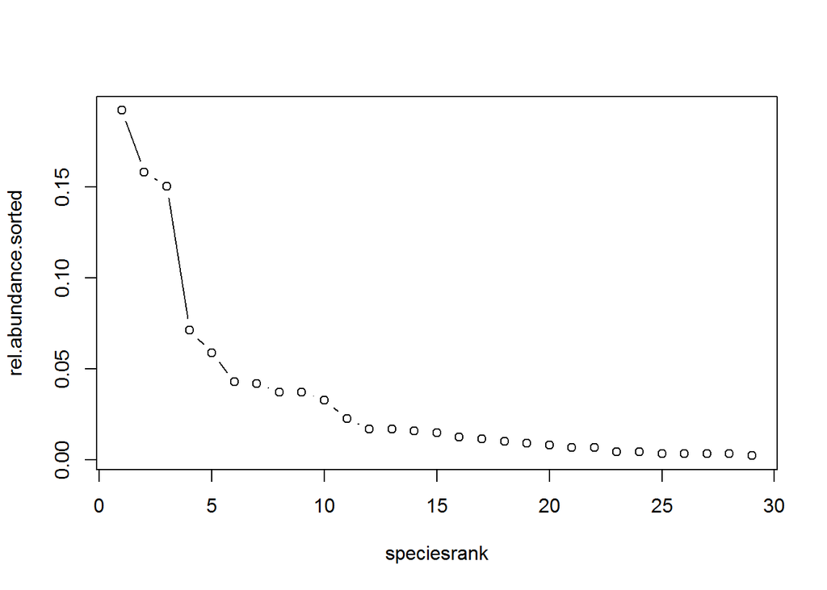

```r
index <- sort(data$Abundance, decreasing=TRUE)
rel.abundance.sorted <- index/N
speciesrank <- 1:S
plot(speciesrank,rel.abundance.sorted,type="b") # in a relative scale
```

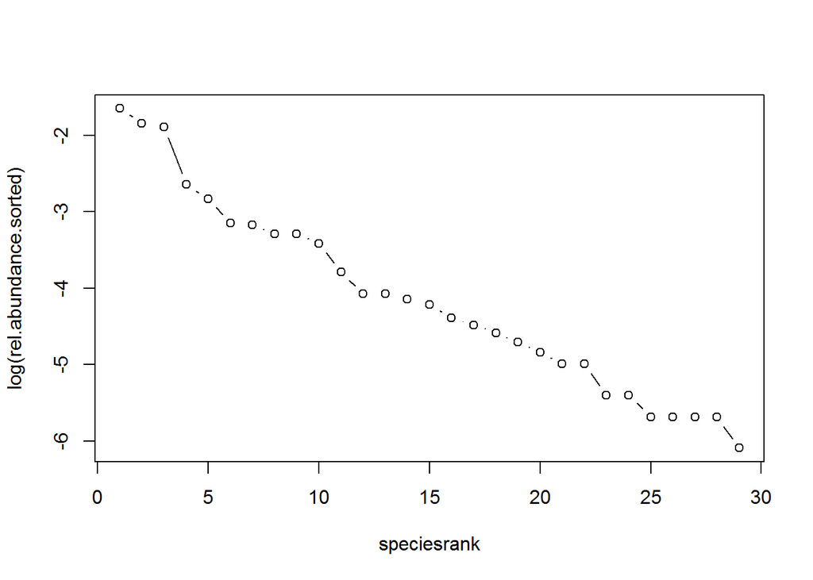

```r
plot(speciesrank,log(rel.abundance.sorted),type="b") # in the log scale
```

5. (1p) Ajustamos la distribución log-serie de Fisher a los datos, usando la función fisherfit del paquete R vegan, estimando el parámetro de diversidad ??.

```r
fisher.alpha(data[,2])
```

```
## [1] 5.752471
```

```r
fisherfit(data[,2])
```

```
##
## Fisher log series model
## No. of species: 29
## Fisher alpha:   5.752471
```

6. (1p) ¿Que interpretación tiene esta estimación? La distribución log-serie de Fisher tiene un solo parámetro p. A la vista de los resultados, cúal seria el valor estimado del parámetro p?

El estimador Fisher alpha se interpreta como el número de especies que están presentes con un individuo. La fiablididad de Fisher alpha depende de la cercanía del parámetro p a 1.

Calculamos p para comprobarlo:

```r
p <- 1-exp(-S/fisher.alpha(data[,2]))
p
```

```
## [1] 0.9935347
```

7. (1p) Ajustamos la serie geométrica a los datos. Realiza una regresión lineal de la abundancia relativa log-transformada de los S especies sobre su rango. El modelo es significativo? Proporciona la recta estimada y el coeficiente de determinación del modelo.

```r
x<- 1:N_especies
lny<- log(sort(data[,2], decreasing =T ))
regresion <- lm(lny~x)
summary(regresion)
```

```
##
## Call:
## lm(formula = lny ~ x)
##
## Residuals:
##      Min       1Q   Median       3Q      Max
## -0.36855 -0.13657 -0.01347  0.04443  0.51362
##
## Coefficients:
##              Estimate Std. Error t value Pr(>|t|)
## (Intercept)  4.810102   0.084382    57.0   <2e-16 ***
## x           -0.144458   0.004913   -29.4   <2e-16 ***
## ---
## Signif. codes:  0 '***' 0.001 '**' 0.01 '*' 0.05 '.' 0.1 ' ' 1
##
## Residual standard error: 0.2214 on 27 degrees of freedom
## Multiple R-squared:  0.9697, Adjusted R-squared:  0.9686
## F-statistic: 864.6 on 1 and 27 DF,  p-value: < 2.2e-16
```

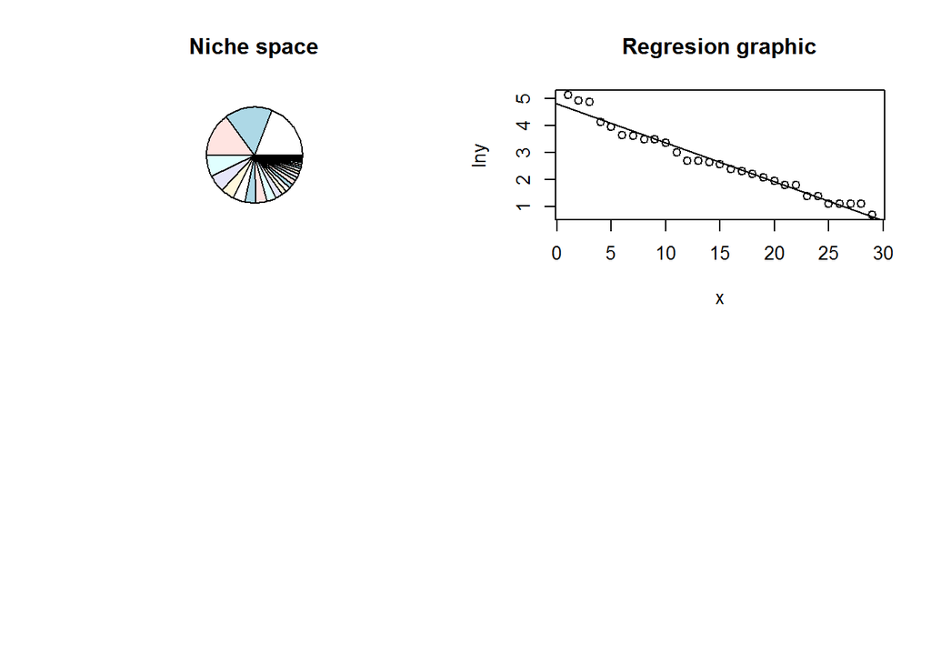

```r
par(mfrow=c(2,2))
pie(sort(data[,2], decreasing=T), labels = NA, main = 'Niche space')
plot(x,lny, main= 'Regresion graphic')
abline(regresion)
```

En el model de regresión lineal de la abundancia relativa, se ha obtenido un p-valor inferior al 5%, por lo que podemos afirmar que el model es significativo (es lineal).

En la gráfica de regresión lineal se confirman los resultados obtenidos con el summary.

8. (1p) Repite el diagrama rango-abudundancia en escala logarítmica, añadiendo la recta de regresión con la función abline. Cuál es vuestra estimación del parámetro k de la serie geométrica?

```r
regresion_rel <- lm(log(rel.abundance.sorted)~speciesrank)
summary(regresion_rel)
```

```
##
## Call:
## lm(formula = log(rel.abundance.sorted) ~ speciesrank)
##
## Residuals:
##      Min       1Q   Median       3Q      Max
## -0.36855 -0.13657 -0.01347  0.04443  0.51362
##
## Coefficients:
##              Estimate Std. Error t value Pr(>|t|)
## (Intercept) -1.974355   0.084382   -23.4   <2e-16 ***
## speciesrank -0.144458   0.004913   -29.4   <2e-16 ***
## ---
## Signif. codes:  0 '***' 0.001 '**' 0.01 '*' 0.05 '.' 0.1 ' ' 1
##
## Residual standard error: 0.2214 on 27 degrees of freedom
## Multiple R-squared:  0.9697, Adjusted R-squared:  0.9686
## F-statistic: 864.6 on 1 and 27 DF,  p-value: < 2.2e-16
```

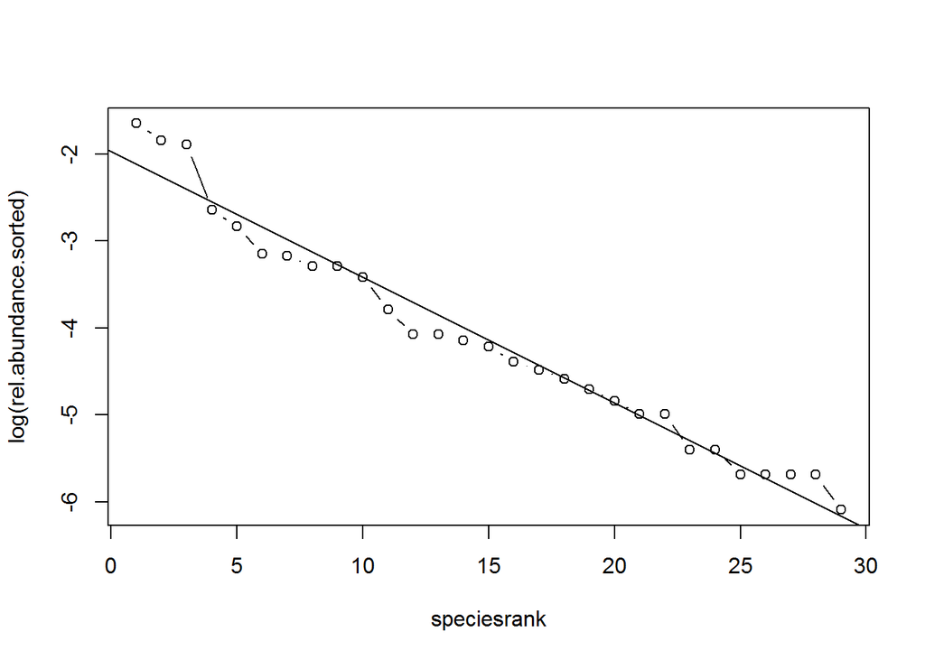

```r
plot(speciesrank,log(rel.abundance.sorted),type="b") # in the log scale
abline(regresion_rel)
```

```r
k <- 1-exp(-0.1444583)
k
```

```
## [1] 0.134509
```

La estimación del parámetro k de la serie geométrica es 0.134509.

9. (1p) Investiga los residuos de esta regresión lineal, y hagais los comentarios que os parecen indicados.

```r
summary(regresion_rel$residuals)
```

```
##     Min.  1st Qu.   Median     Mean  3rd Qu.     Max.
## -0.36855 -0.13657 -0.01347  0.00000  0.04443  0.51362
```

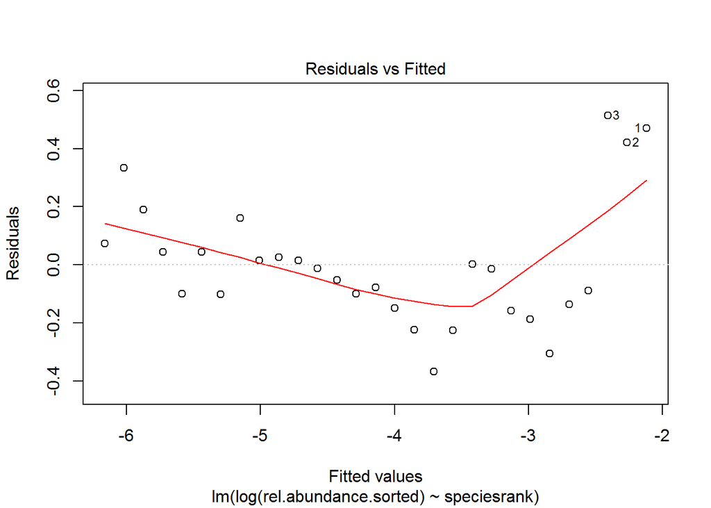

```r
plot(regresion_rel, which=1)
```

Se observa una línia curvada, poco horizontal, por lo que parece haber algún problema de aleatoriedad. Cabe destacar que las tres especies con mayor número de individuos son outliers.

10. (1p) Calcula un intervalo de confianza 95% para el pendiente del modelo, y usa los resultados para hacer un intervalo de confianza 95% para el parámetro k de la serie geométrica.

```r
confint(regresion_rel)
```

```
##                  2.5 %     97.5 %
## (Intercept) -2.1474929 -1.8012173
## speciesrank -0.1545388 -0.1343779
```

11. (1p) Ajustamos el modelo del bastón roto (broken stick model) a los datos, usando la función rad.null del paquete vegan, dando el vector con las cuentas de los S especies como argumento. Con plot(rad.null(x)) se pueden graficar los resultados. ¿El modelo del bastón roto se ajusta bien a los datos?

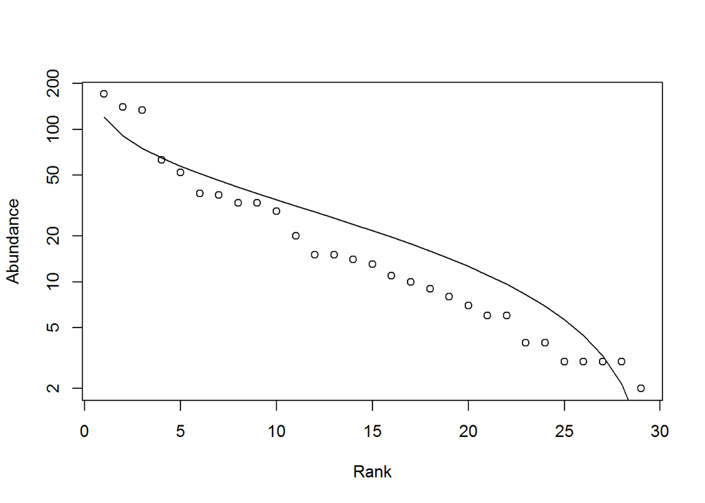

```r
out <- rad.null(data$Abundance)
yhat <- fitted(out)
plot(out)
```

12. (1p) Calcula el valor del índice de Shannon para estos datos. Calcula también, consultando las transparencies de teoria, su varianza. Asumiendo normalidad, calcula un intervalo de confianza de 95% para el verdadero valor de este ´indice